# DATA 624 Spring 2019: Homework-1

Ahmed Sajjad, Harpreet Shoker, Jagruti Solao, Chad Smith, Todd Weigel

March 12, 2019

```r
library(mlbench)
library(tidyr)
library(dplyr)
```

```r
library(ggplot2)
library(forecast)
library(fma)
library(fpp2)
library(gridExtra)
```

##### **HA# 2.3**

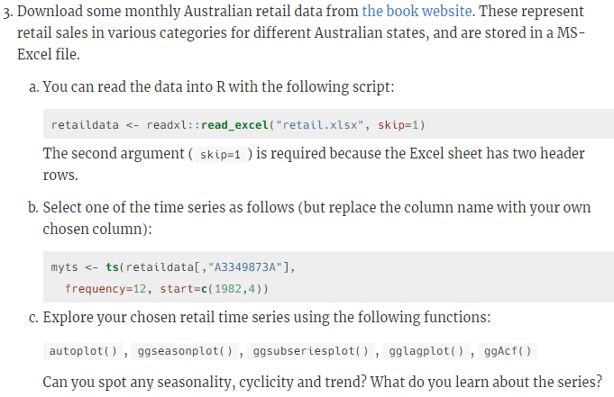

#### a) You can read the data into R with the following script:

```r
retaildata <- readxl::read_excel("retail.xlsx", skip=1)
```

The second argument (skip=1) is required because the Excel sheet has two header rows.

### b) Select one of the time series as follows (but replace the column name with your own chosen column):

```r
myts <- ts(retaildata[,"A3349873A"],frequency=12, start=c(1982,4))
head(myts)
```

```
##       Apr  May  Jun  Jul  Aug  Sep
## 1982 62.4 63.1 59.6 61.9 60.7 61.2
```

### c) Explore your chosen retail time series using the following functions:

autoplot(), ggseasonplot(), ggsubseriesplot(), gglagplot(), ggAcf()

Can you spot any seasonality, cyclicity and trend? What do you learn about the series?

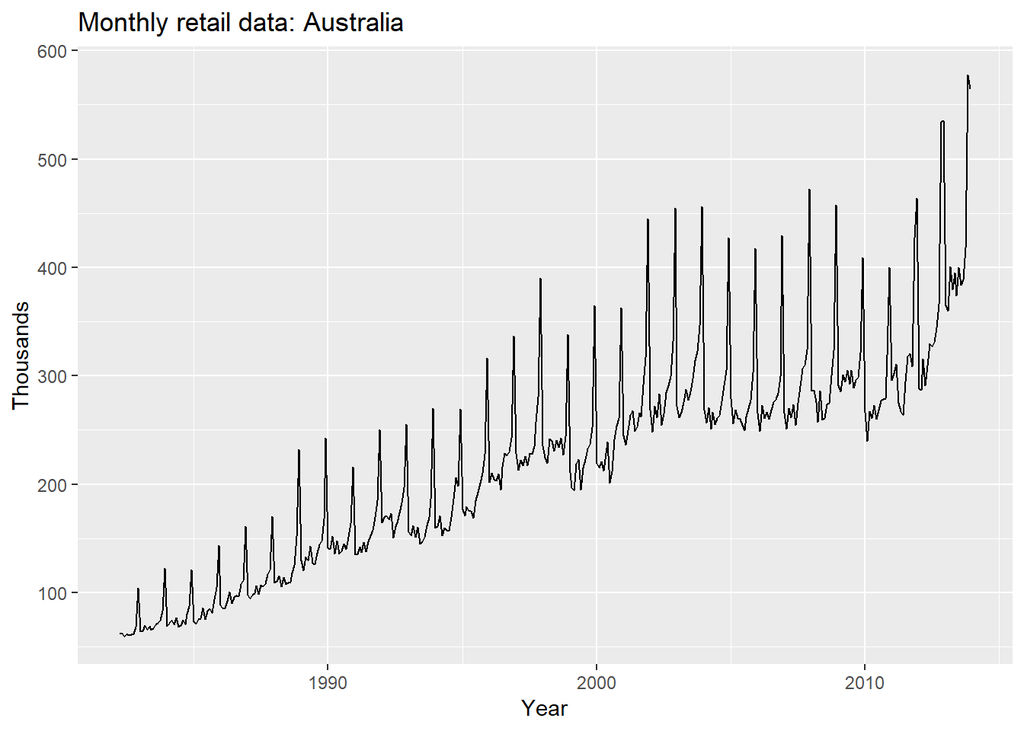

```r
autoplot(myts) +
  ggtitle("Monthly retail data: Australia") +
  xlab("Year") +
  ylab("Thousands")
```

Time series plot reveals following features:

1. There is continuous increment for business in retail sector data from 1982 to2012.
2. Sudden dip was observed in year 2000 and 2010 may be due to resession and slowdown of market.
3. Retail market shows dips for start of year and gradual highs towards end of it.

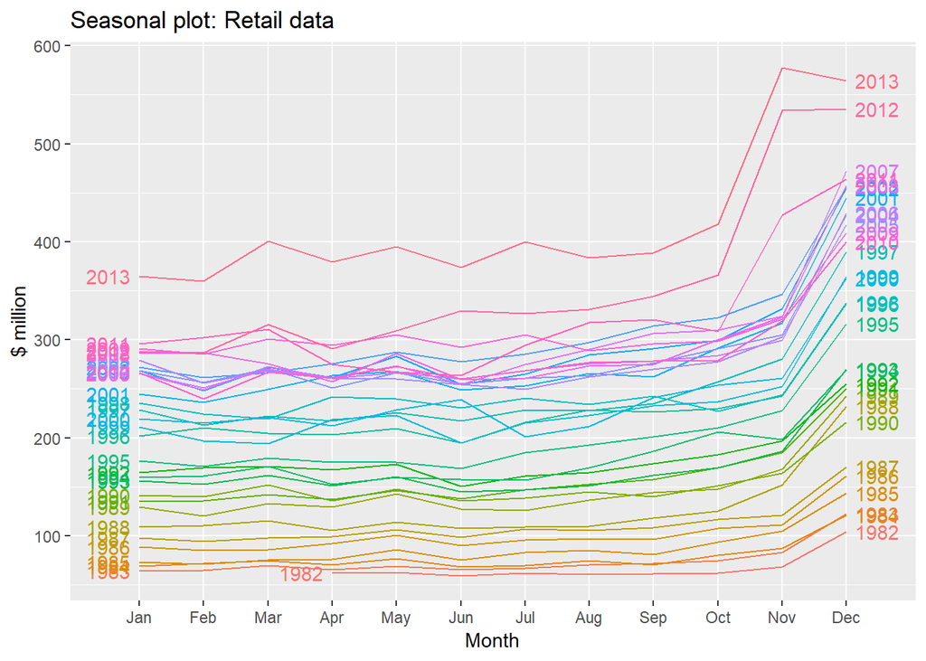

```r
ggseasonplot(myts, year.labels=TRUE, year.labels.left=TRUE) +
  ylab("$ million") +
  ggtitle("Seasonal plot: Retail data")
```

A seasonal plot allows the underlaying pattern to be seen more clearly and are useful in identifying years in which the pattern changes. In our case, above plot makes it clear that there is large jump in retail sector by end of year , mostly in Nov and Dec.patterns also make us notice that there are unsual dips in retail sector around Jun ,July.Seasonal plot is similar to time plot except the data are plotted against the individual “seasons” in which data were observed.There can also be variation made in plot using polar co-ordinates.

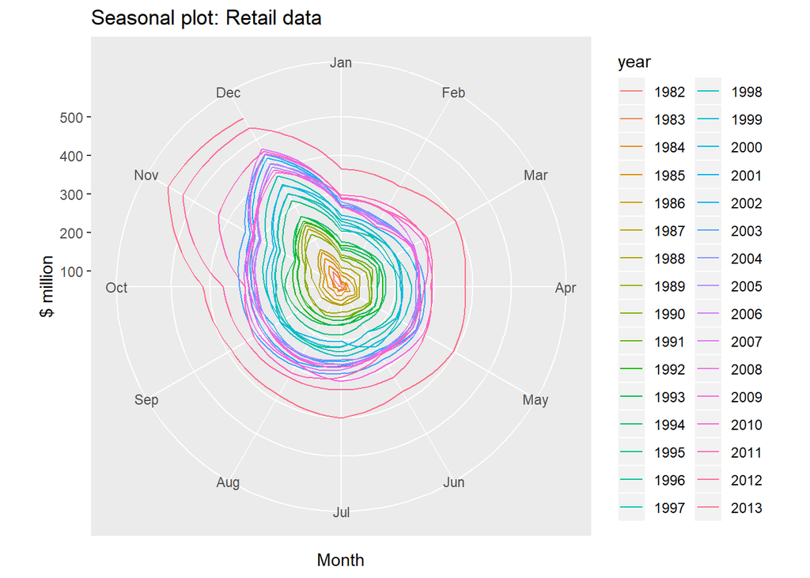

```r
ggseasonplot(myts, polar = TRUE) +
  ylab("$ million") +
  ggtitle("Seasonal plot: Retail data")
```

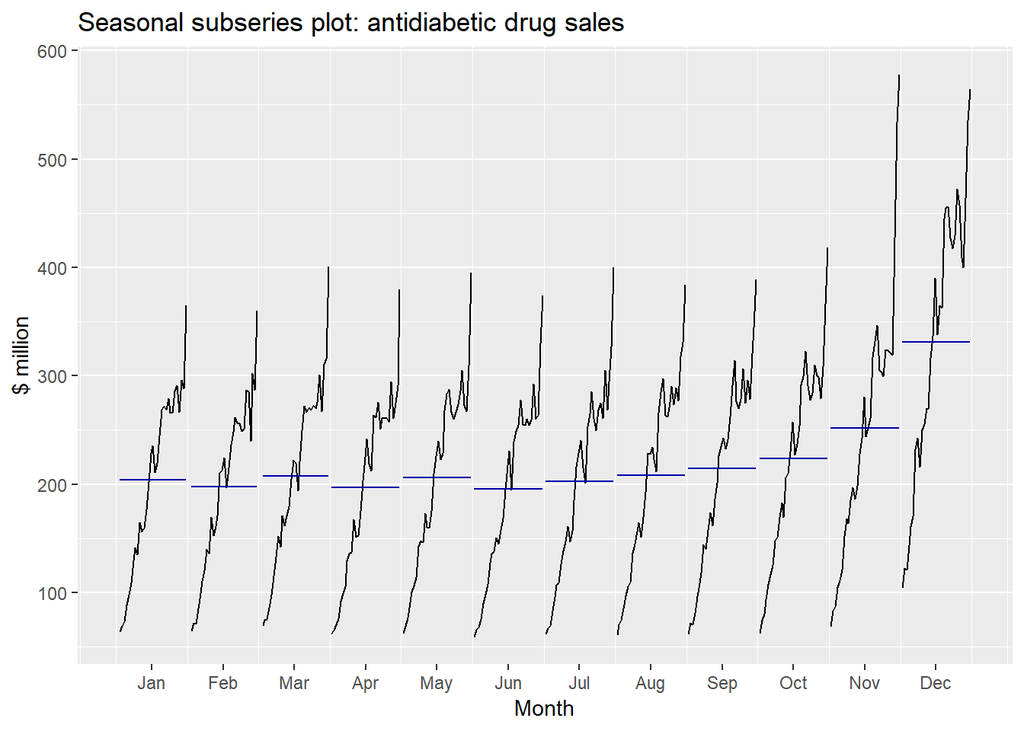

```r
ggsubseriesplot(myts) +
  ylab("$ million") +
  ggtitle("Seasonal subseries plot: antidiabetic drug sales")
```

Seasonality plot validates our clain that retail sector has maximum business in November and December each year. The horizontal line indicates means for each month.This form of plot enables the underlaying seasonal pattern to be seen clearly,also showing changes in seasonality over time.

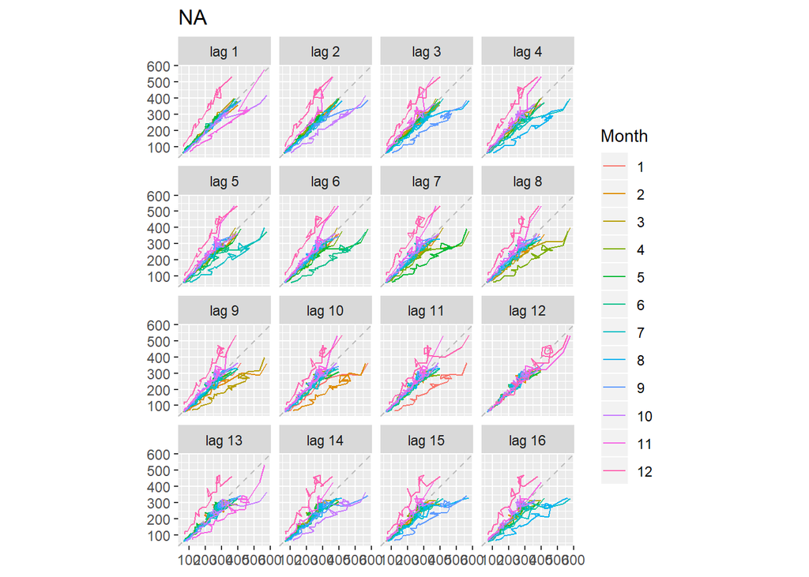

```r
gglagplot(myts)
```

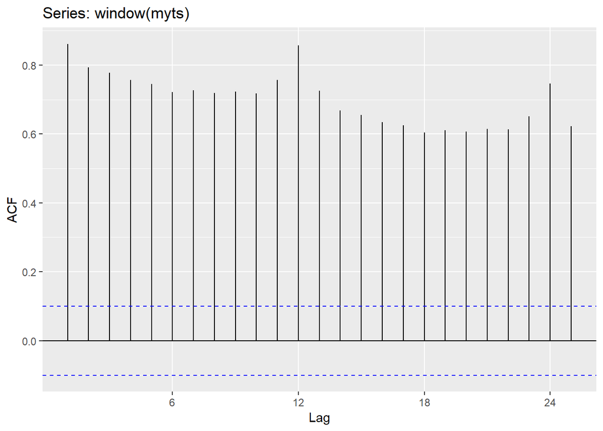

```r
ggAcf(window(myts),start = 1982)
```

Figure 6 shows Autocorrelation function for monthly retail data for Australia. As we can observe there is no negative co-relation observed. The dashed blue lines indicate whether the correlations are significantly different from zero.

##### **HA# 2.7**

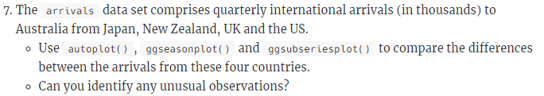

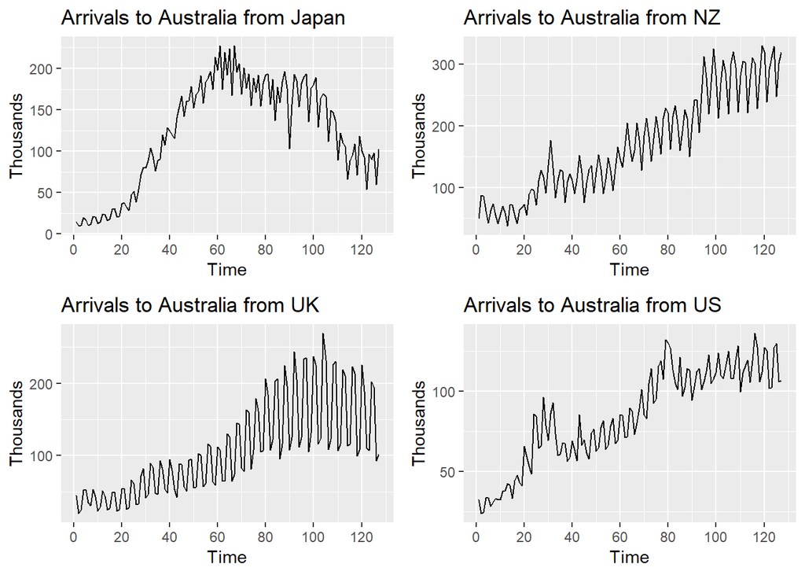

```r
myts1 <- ts(arrivals[,"Japan"])
a <- autoplot(myts1) + ggtitle("Arrivals to Australia from Japan") + ylab("Thousands")
myts2 <- ts(arrivals[,"NZ"])
b <- autoplot(myts2) + ggtitle("Arrivals to Australia from NZ") + ylab("Thousands")
myts3 <- ts(arrivals[,"UK"])
c <- autoplot(myts3) + ggtitle("Arrivals to Australia from UK") + ylab("Thousands")
myts4 <- ts(arrivals[,"US"])
d <- autoplot(myts4) + ggtitle("Arrivals to Australia from US") + ylab("Thousands")
grid.arrange(a,b,c,d, nrow = 2)
```

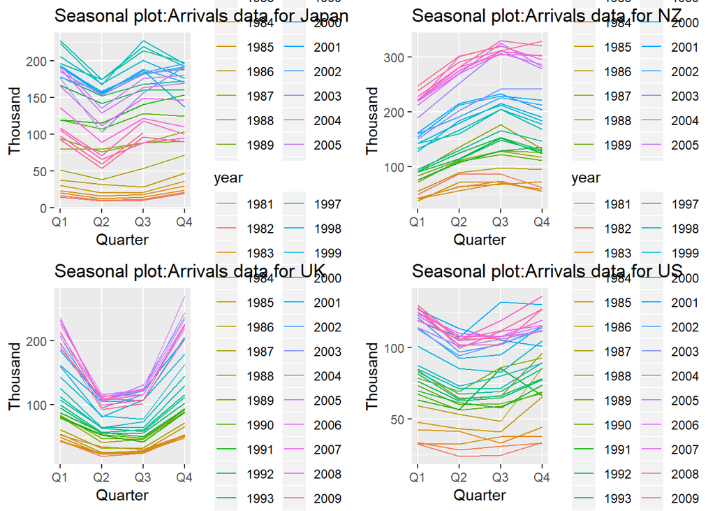

```r
a1 <- ggseasonplot(arrivals[,"Japan"]) + ylab("Thousand") +ggtitle("Seasonal plot:Arrivals data for Japan")
b1 <- ggseasonplot(arrivals[,"NZ"]) + ylab("Thousand") +ggtitle("Seasonal plot:Arrivals data for NZ")
c1 <- ggseasonplot(arrivals[,"UK"]) + ylab("Thousand") +ggtitle("Seasonal plot:Arrivals data for UK")
d1 <- ggseasonplot(arrivals[,"US"]) + ylab("Thousand") +ggtitle("Seasonal plot:Arrivals data for US")
grid.arrange(a1,b1,c1,d1, nrow = 2)
```

The most unusual observation is obsereved for arrival data in ‘UK’ for Q2 and Q3.The arrival numbers are drastically down but gradually increased in Q4.At the same time, New zealand shows highest arrival rates for Q3.

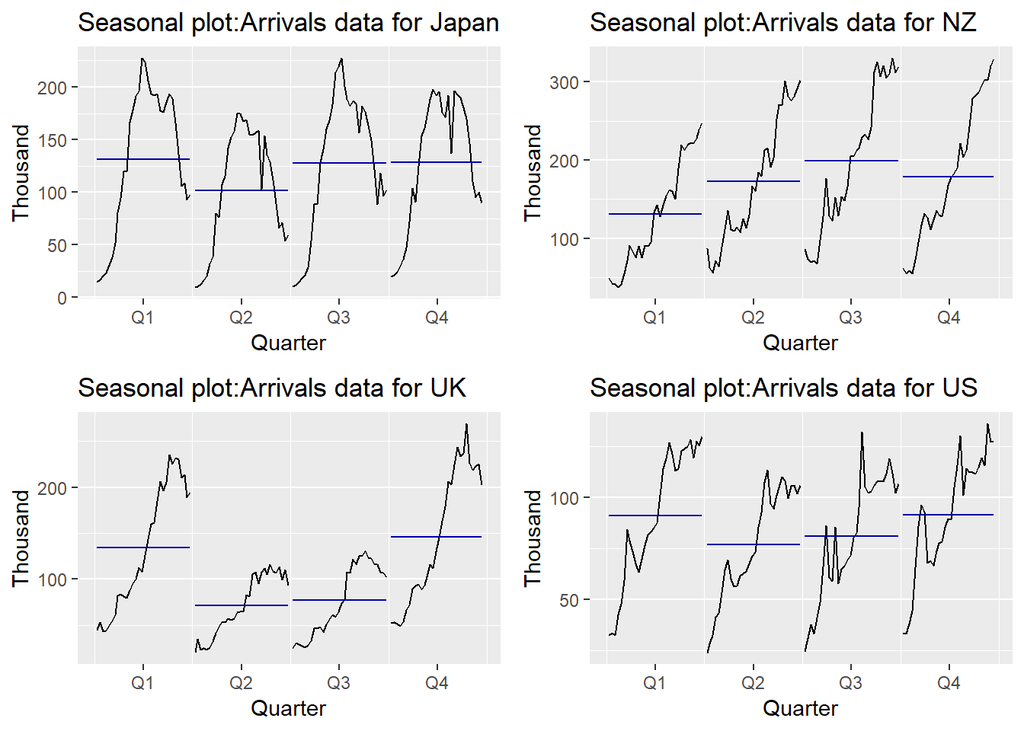

```r
a2 <- ggsubseriesplot(arrivals[,"Japan"]) + ylab("Thousand") +ggtitle("Seasonal plot:Arrivals data for Japan")
b2 <- ggsubseriesplot(arrivals[,"NZ"]) + ylab("Thousand") +ggtitle("Seasonal plot:Arrivals data for NZ")
c2 <- ggsubseriesplot(arrivals[,"UK"]) + ylab("Thousand") +ggtitle("Seasonal plot:Arrivals data for UK")
d2 <- ggsubseriesplot(arrivals[,"US"]) + ylab("Thousand") +ggtitle("Seasonal plot:Arrivals data for US")
grid.arrange(a2,b2,c2,d2, nrow = 2)
```

##### **HA# 2.10**

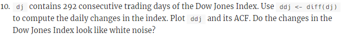

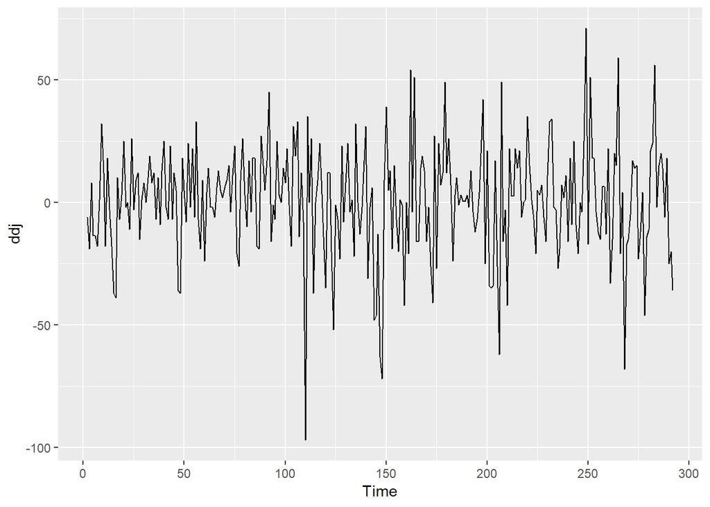

```r
ddj <- diff(dj)
autoplot(ddj)
```

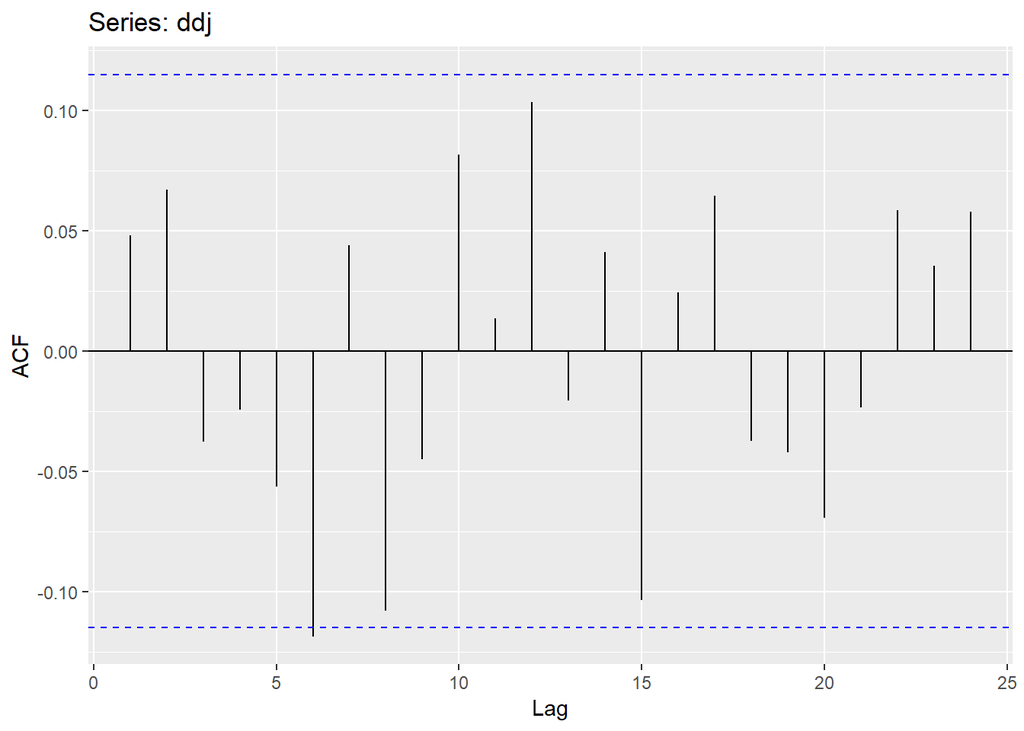

```r
ggAcf(ddj)
```

[figure not shown]

##### **HA# 3.8**

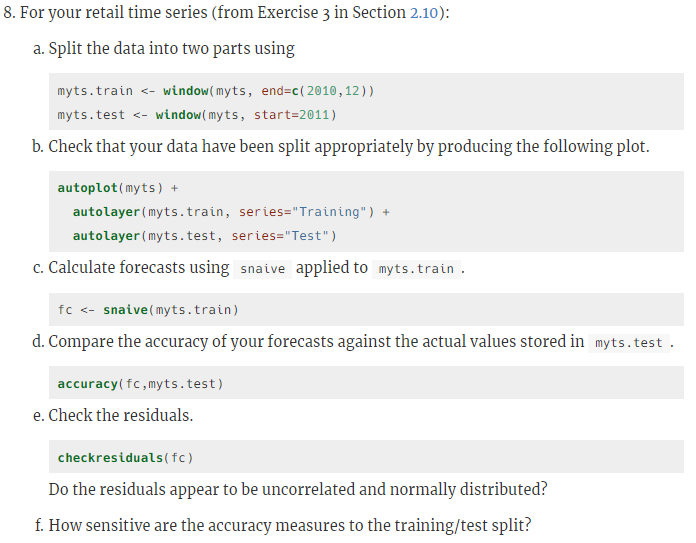

##### For your retail time series (from Exercise 3 in Section 2.10):

Loading the reatil data

```r
retaildata <- readxl::read_excel("retail.xlsx", skip=1)
myts <- ts(retaildata[,"A3349873A"],
  frequency=12, start=c(1982,4))
```

##### a) Split the data into two parts using

```r
myts.train <- window(myts, end=c(2010,12))
myts.test <- window(myts, start=2011)
```

##### b) Check that your data have been split appropriately by producing the following plot.

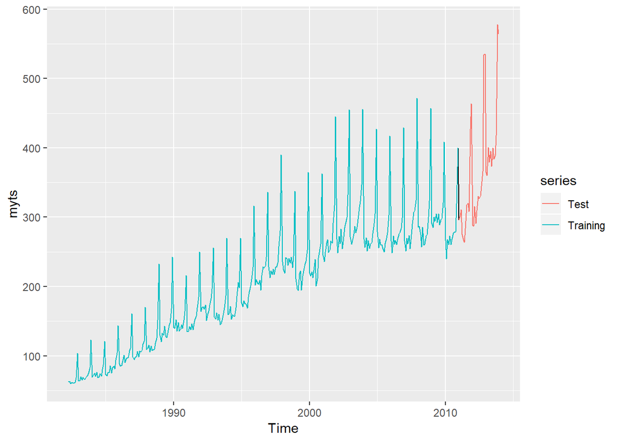

```r
autoplot(myts) + autolayer(myts.train, series="Training") +
  autolayer(myts.test, series="Test")
```

##### c) Calculate forecasts using snaive applied to myts.train.

```r
fc <- snaive(myts.train)
```

##### d) Compare the accuracy of your forecasts against the actual values stored in myts.test.

```r
accuracy(fc,myts.test)
```

```
##                     ME     RMSE      MAE       MPE      MAPE     MASE
## Training set  7.772973 20.24576 15.95676  4.702754  8.109777 1.000000
## Test set     55.300000 71.44309 55.78333 14.900996 15.082019 3.495907
##                   ACF1 Theil's U
## Training set 0.7385090        NA
## Test set     0.5315239  1.297866
```

##### e) Check the residuals.Do the residuals appear to be uncorrelated and normally distributed?

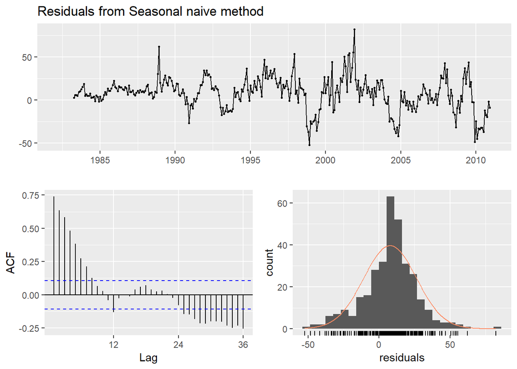

```
##
##  Ljung-Box test
##
## data:  Residuals from Seasonal naive method
## Q* = 624.45, df = 24, p-value < 2.2e-16
##
## Model df: 0.   Total lags used: 24
```

```r
checkresiduals(fc)
```

From the above it seems like residuals are correlated to each other. Residuals are not normally distributed.

##### f) How sensitive are the accuracy measures to the training/test split?

```r
myts2.train <- window(myts, end=c(2011,12))
myts2.test <- window(myts, start=2012)
fc2 <- snaive(myts2.train)
accuracy(fc2,myts.test)
```

```
##                     ME     RMSE      MAE       MPE      MAPE   MASE
## Training set  8.828696 21.81237 16.76145  4.922591  8.223701 1.0000
## Test set     65.429167 78.69376 67.34583 15.853615 16.520064 4.0179
##                   ACF1 Theil's U
## Training set 0.7198310        NA
## Test set     0.7328968  1.356191
```

##### **HA# 6.2**

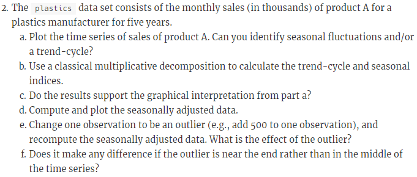

##### a) Plot the time series of sales of product A. Can you identify seasonal fluctuations and/or a trend-cycle?

Loading the required libraries and plastics data

```r
plastics
```

```
##    Jan  Feb  Mar  Apr  May  Jun  Jul  Aug  Sep  Oct  Nov  Dec
## 1  742  697  776  898 1030 1107 1165 1216 1208 1131  971  783
## 2  741  700  774  932 1099 1223 1290 1349 1341 1296 1066  901
## 3  896  793  885 1055 1204 1326 1303 1436 1473 1453 1170 1023
## 4  951  861  938 1109 1274 1422 1486 1555 1604 1600 1403 1209
## 5 1030 1032 1126 1285 1468 1637 1611 1608 1528 1420 1119 1013
```

```r
ts(plastics)
```

```
## Time Series:
## Start = 1
## End = 60
## Frequency = 1
##  [1]  742  697  776  898 1030 1107 1165 1216 1208 1131  971  783  741  700
## [15]  774  932 1099 1223 1290 1349 1341 1296 1066  901  896  793  885 1055
## [29] 1204 1326 1303 1436 1473 1453 1170 1023  951  861  938 1109 1274 1422
## [43] 1486 1555 1604 1600 1403 1209 1030 1032 1126 1285 1468 1637 1611 1608
## [57] 1528 1420 1119 1013
```

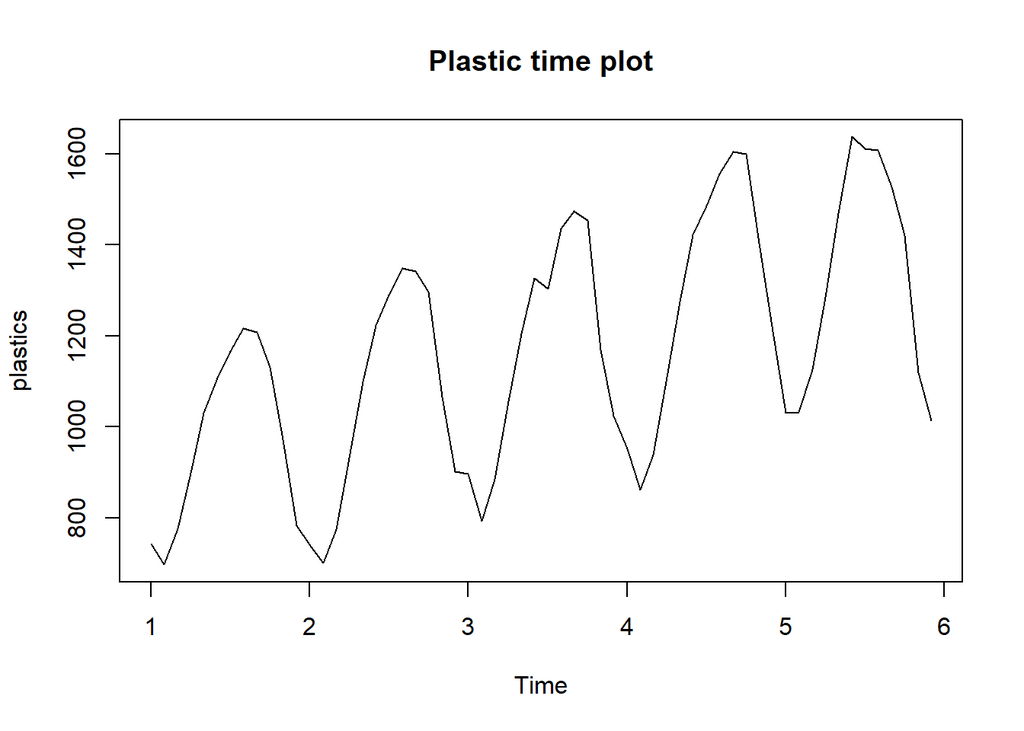

```r
plot(plastics,main = 'Plastic time plot')
```

From the above Time plot we can see there are seasonal fluctuations and upward trend. Seasonal sales are peaking in summer. Overall plot shows positive trnd with sales increasing yearly.

##### b) Use a classical multiplicative decomposition to calculate the trend-cycle and seasonal indices.

```r
plastic_model <- decompose(plastics, type="multiplicative")
trend <- plastic_model$trend #calculating trend
trend
```

```
##         Jan       Feb       Mar       Apr       May       Jun       Jul
## 1        NA        NA        NA        NA        NA        NA  976.9583
## 2 1000.4583 1011.2083 1022.2917 1034.7083 1045.5417 1054.4167 1065.7917
## 3 1117.3750 1121.5417 1130.6667 1142.7083 1153.5833 1163.0000 1170.3750
## 4 1208.7083 1221.2917 1231.7083 1243.2917 1259.1250 1276.5833 1287.6250
## 5 1374.7917 1382.2083 1381.2500 1370.5833 1351.2500 1331.2500        NA
##         Aug       Sep       Oct       Nov       Dec
## 1  977.0417  977.0833  978.4167  982.7083  990.4167
## 2 1076.1250 1084.6250 1094.3750 1103.8750 1112.5417
## 3 1175.5000 1180.5417 1185.0000 1190.1667 1197.0833
## 4 1298.0417 1313.0000 1328.1667 1343.5833 1360.6250
## 5        NA        NA        NA        NA        NA
```

```r
seasonal <- plastic_model$seasonal # calculating seasonal indices
seasonal
```

```
##         Jan       Feb       Mar       Apr       May       Jun       Jul
## 1 0.7670466 0.7103357 0.7765294 0.9103112 1.0447386 1.1570026 1.1636317
## 2 0.7670466 0.7103357 0.7765294 0.9103112 1.0447386 1.1570026 1.1636317
## 3 0.7670466 0.7103357 0.7765294 0.9103112 1.0447386 1.1570026 1.1636317
## 4 0.7670466 0.7103357 0.7765294 0.9103112 1.0447386 1.1570026 1.1636317
## 5 0.7670466 0.7103357 0.7765294 0.9103112 1.0447386 1.1570026 1.1636317
##         Aug       Sep       Oct       Nov       Dec
## 1 1.2252952 1.2313635 1.1887444 0.9919176 0.8330834
## 2 1.2252952 1.2313635 1.1887444 0.9919176 0.8330834
## 3 1.2252952 1.2313635 1.1887444 0.9919176 0.8330834
## 4 1.2252952 1.2313635 1.1887444 0.9919176 0.8330834
## 5 1.2252952 1.2313635 1.1887444 0.9919176 0.8330834
```

##### c) Do the results support the graphical interpretation from part a?

Yes, the results support the graphical interpretation.The graph indicates that the summer months have higher seasonal indices than the winter months

##### d) Compute and plot the seasonally adjusted data.

Here we are showing the trend-cycle component and the seasonally adjusted data, along with the original data.

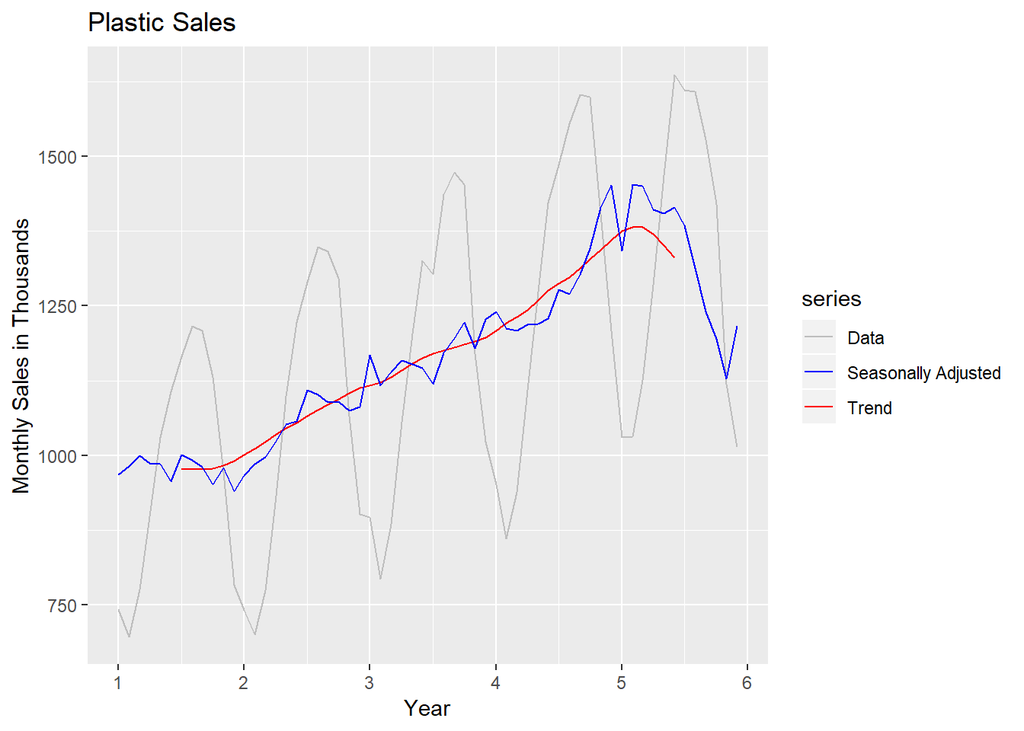

```r
autoplot(plastics, series="Data") +
  autolayer(trendcycle(plastic_model), series="Trend") +
  autolayer(seasadj(plastic_model), series="Seasonally Adjusted") +
  xlab("Year") + ylab("Monthly Sales in Thousands") +
  ggtitle("Plastic Sales") +
  scale_colour_manual(values=c("gray","blue","red"), breaks=c("Data","Seasonally Adjusted","Trend"))
```

##### e) Change one observation to be an outlier (e.g., add 500 to one observation), and recompute the seasonally adjusted data. What is the effect of the outlier?

Here we are adding 500 to 29th observation

```r
outlier_plastic <- plastics
outlier_plastic[29] <- outlier_plastic[29] + 500
outlier_model <- decompose(outlier_plastic, type = "multiplicative")
```

Plot showing the trend-cycle component and the seasonally adjusted data, along with the original data with modified outlier data.

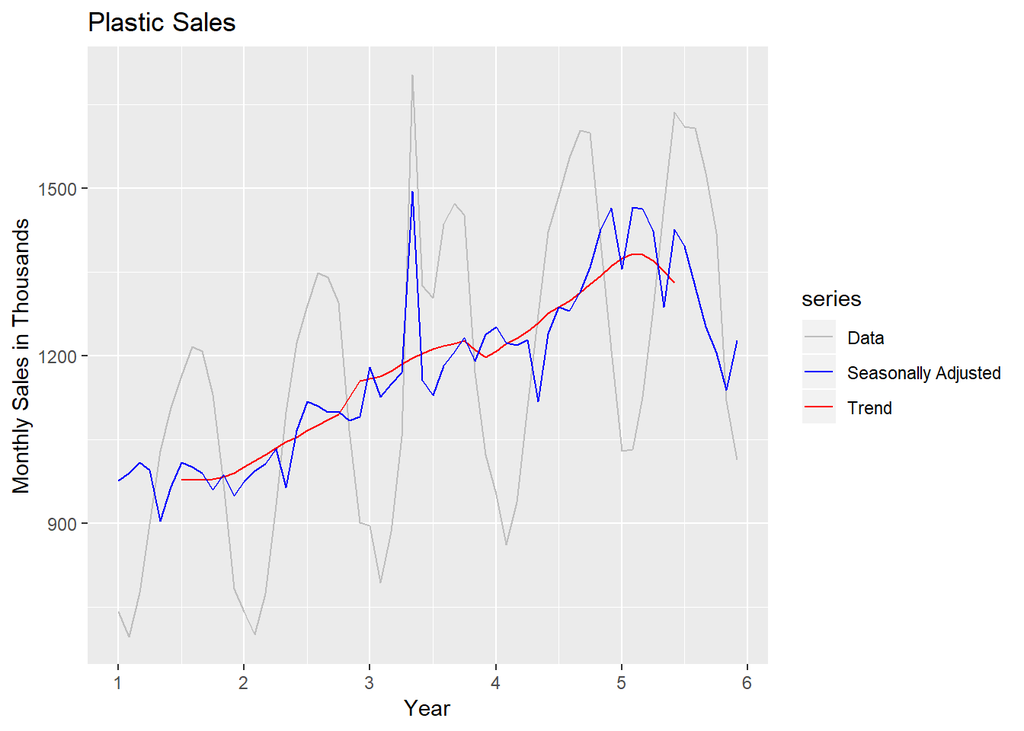

```r
autoplot(outlier_plastic, series = "Data") +
  autolayer(trendcycle(outlier_model), series = "Trend") +
  autolayer(seasadj(outlier_model), series = "Seasonally Adjusted") +
  xlab("Year") + ylab("Monthly Sales in Thousands") +
  ggtitle("Plastic Sales") +
  scale_color_manual(values=c("gray", "blue", "red"), breaks=c("Data", "Seasonally Adjusted", "Trend"))
```

We can see from the above graph that outlier doesnot have much effects on Trend cycle but it is highly effecting the seasonal data

##### f) Does it make any difference if the outlier is near the end rather than in the middle of the time series?

Here we are adding 500 to 52nd observation

```r
outlierend_plastic <- plastics
outlierend_plastic[52] <- outlierend_plastic[52] + 500
outlierend_model <- decompose(outlierend_plastic, type = "multiplicative")
```

Plot showing the trend-cycle component and the seasonally adjusted data, along with the original data with modified outlier data

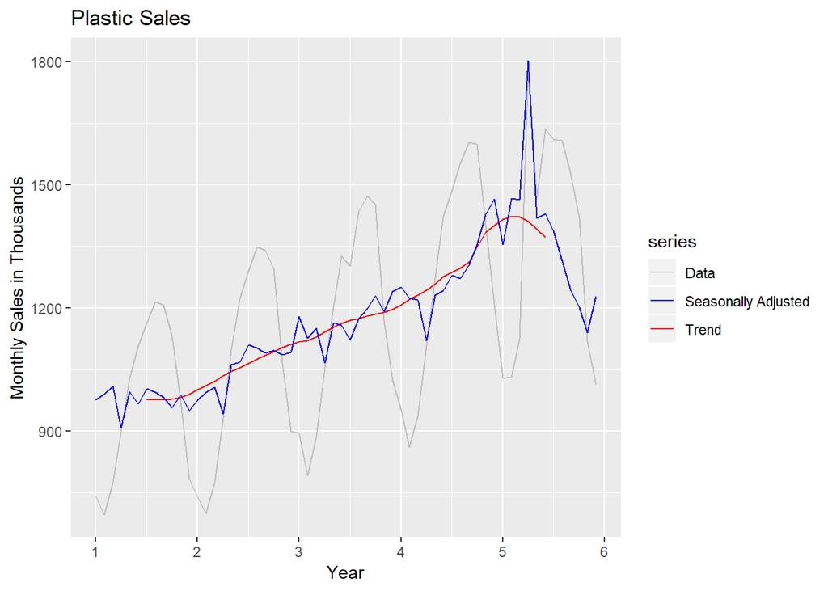

```r
autoplot(outlierend_plastic, series = "Data") +
  autolayer(trendcycle(outlierend_model), series = "Trend") +
  autolayer(seasadj(outlierend_model), series = "Seasonally Adjusted") +
  xlab("Year") + ylab("Monthly Sales in Thousands") +
  ggtitle("Plastic Sales") +
  scale_color_manual(values=c("gray", "blue", "red"), breaks=c("Data", "Seasonally Adjusted", "Trend"))
```

We can conclude that an outlier causes a spike in the month it is present by increasing seasonality index of that month.

##### **HA# 6.6**

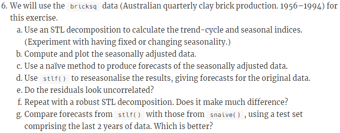

##### a) Use an STL decomposition to calculate the trend-cycle and seasonal indices. (Experiment with having fixed or changing seasonality.)

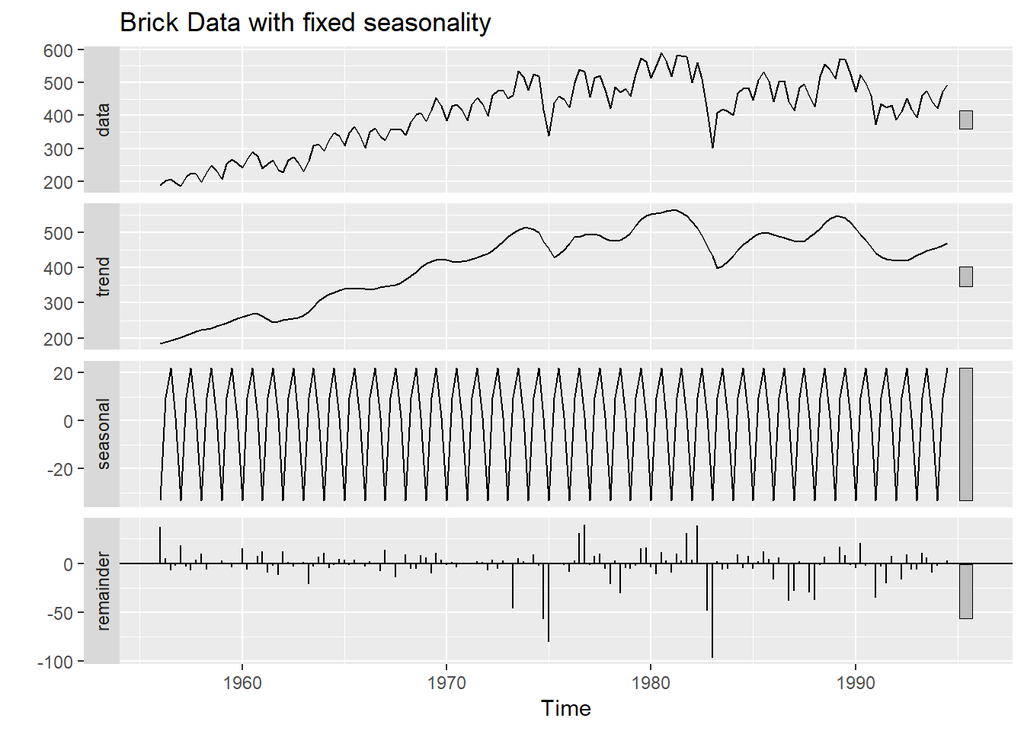

```r
stl_brickfixed <- stl(bricksq, s.window = "periodic",robust = TRUE)
autoplot(stl_brickfixed) +ggtitle("Brick Data with fixed seasonality")
```

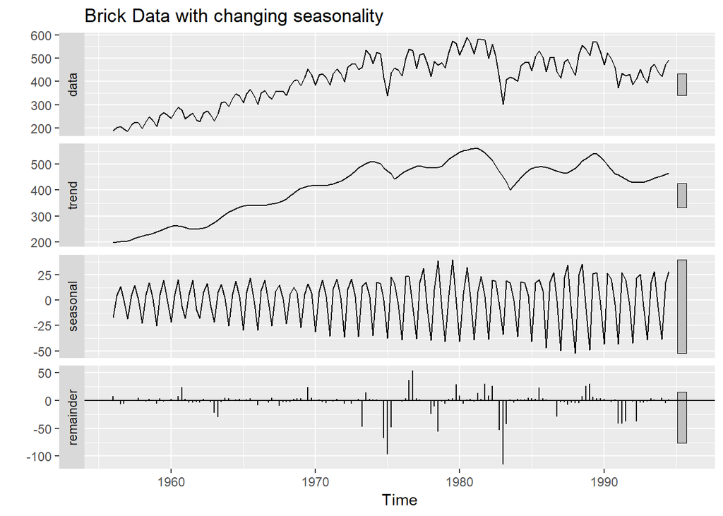

```r
stl_brickchange <- stl(bricksq,s.window = 5,robust = TRUE)
autoplot(stl_brickchange) +ggtitle("Brick Data with changing seasonality")
```

##### b) Compute and plot the seasonally adjusted data.

Here we are showing the trend-cycle component and the seasonally adjusted data, along with the original data.

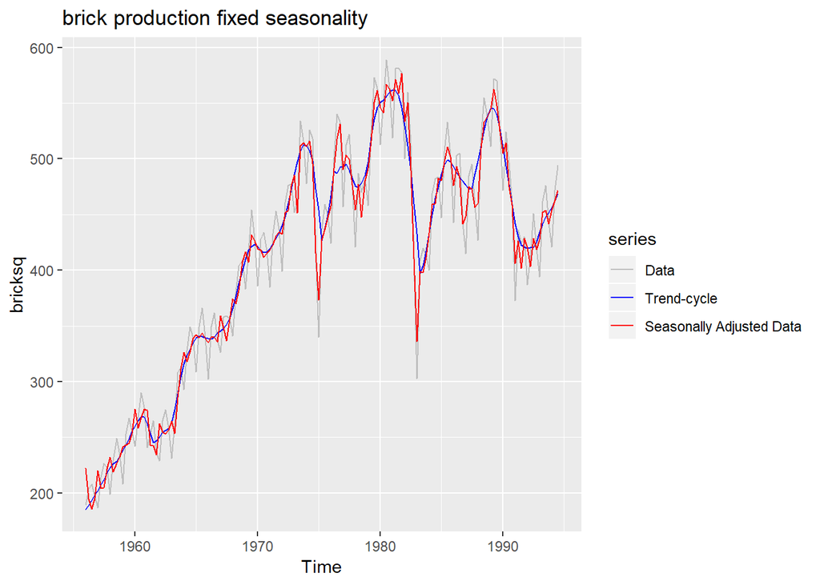

```r
# plot data which are decomposed by STL with fixed seasonality
autoplot(bricksq, series = "Data") +
  autolayer(trendcycle(stl_brickfixed),
            series = "Trend-cycle") +
  autolayer(seasadj(stl_brickfixed),
            series = "Seasonally Adjusted Data") +
  ggtitle("brick production fixed seasonality") +
  scale_color_manual(values = c("gray", "red", "blue"),
                     breaks = c("Data", "Trend-cycle", "Seasonally Adjusted Data"))
```

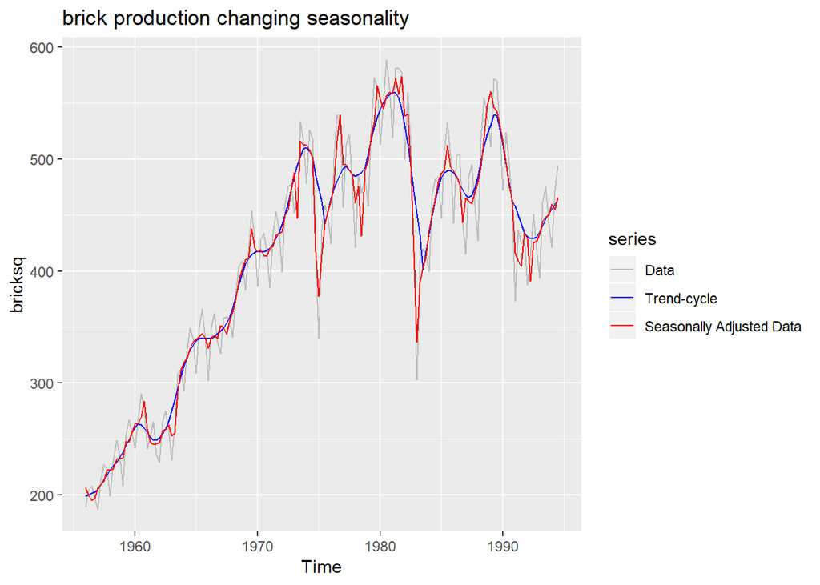

```r
# plot data which are decomposed by STL with changing seasonality
autoplot(bricksq, series = "Data") +
  autolayer(trendcycle(stl_brickchange),
            series = "Trend-cycle") +
  autolayer(seasadj(stl_brickchange),
            series = "Seasonally Adjusted Data") +
  ggtitle("brick production changing seasonality") +
  scale_color_manual(values = c("gray", "red", "blue"),
                     breaks = c("Data", "Trend-cycle", "Seasonally Adjusted Data"))
```

##### c) Use a naÃ¯ve method to produce forecasts of the seasonally adjusted data.

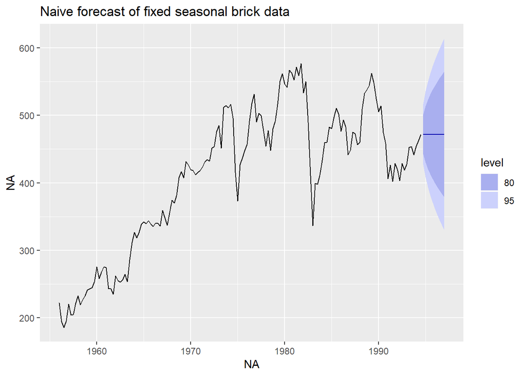

```r
stl_brickfixed %>% seasadj() %>% naive() %>% autoplot() +
  ggtitle(label = "Naive forecast of fixed seasonal brick data")
```

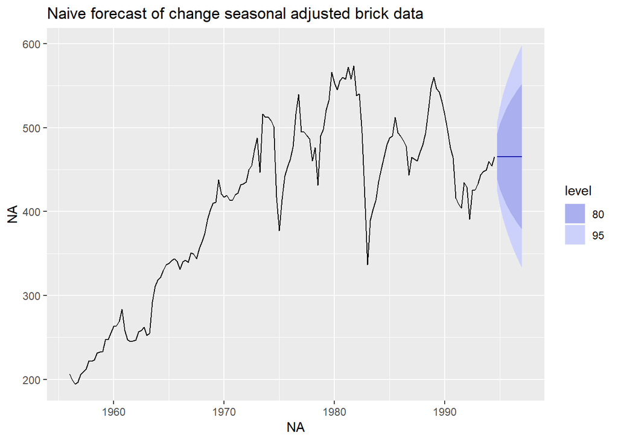

```r
stl_brickchange %>% seasadj() %>% naive() %>% autoplot() +
  ggtitle(label = "Naive forecast of change seasonal adjusted brick data")
```

From the above we can see that the prediction intervals of seasonally adjusted data decomposed by STL with changing seasonality have smaller range than the one with fixed seasonality. It happened because the variance of the remainder component decreased when the seasonality can be changed.

##### d) Use stlf() to reseasonalise the results, giving forecasts for the original data.

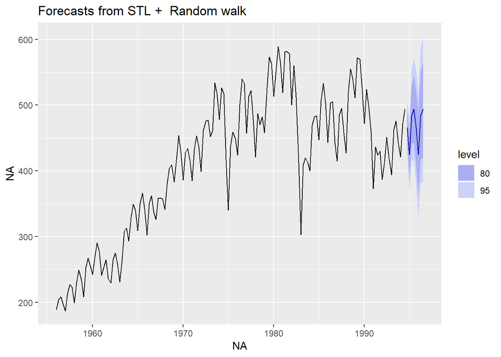

```r
fcast <- stlf(bricksq, method='naive')
autoplot(fcast)
```

##### e) Do the residuals look uncorrelated?

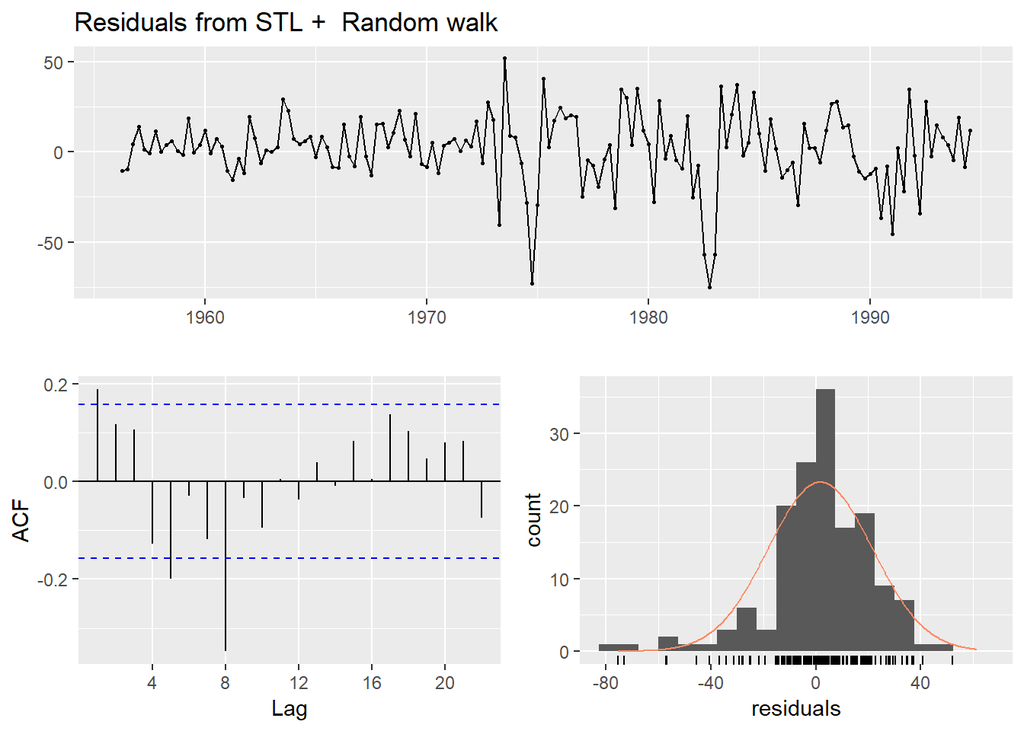

```
##
##  Ljung-Box test
##
## data:  Residuals from STL +  Random walk
## Q* = 40.829, df = 8, p-value = 2.244e-06
##
## Model df: 0.   Total lags used: 8
```

```r
checkresiduals(fcast)
```

The residuals are correlated with each other.

##### f) Repeat with a robust STL decomposition. Does it make much difference?

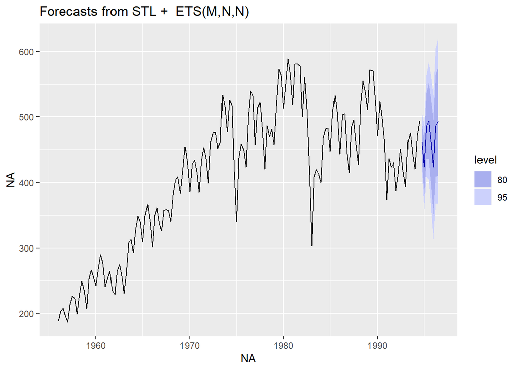

```r
stlf_brickrobust <- stlf(bricksq, robust = TRUE)
autoplot(stlf_brickrobust)
```

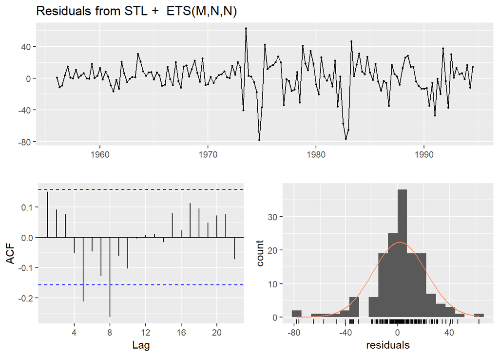

```
##
##  Ljung-Box test
##
## data:  Residuals from STL +  ETS(M,N,N)
## Q* = 28.163, df = 6, p-value = 8.755e-05
##
## Model df: 2.   Total lags used: 8
```

```r
checkresiduals(stlf_brickrobust)
```

It looked like the autocorrelations became lower generally, but there are still some high values left.

##### g) Compare forecasts from stlf() with those from snaive(), using a test set comprising the last 2 years of data. Which is better?

Splitting data into test and train data set and then applying stlf and snaive on the train data.

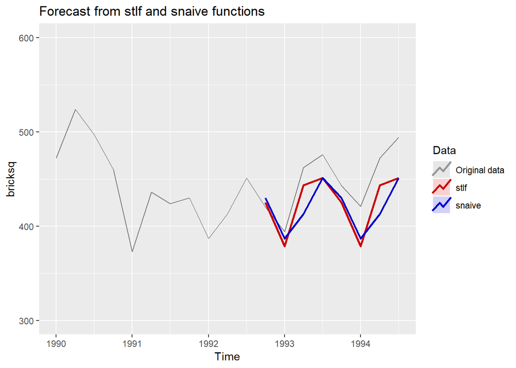

```r
#subsetting train data set leaving last 2 years
train_brick <- subset(bricksq,
                        end = length(bricksq) - 8)
#subsetting test data set including only last 2 years data
test_brick <- subset(bricksq,
                        start = length(bricksq) - 7)

snaive_bricksq_train <- snaive(train_brick)

stlf_bricksq_train <- stlf(train_brick, robust = TRUE)
# plot data and forecast results
autoplot(bricksq, series = "Original data") +
  autolayer(stlf_bricksq_train, PI = FALSE, size = 1,
            series = "stlf") +
  autolayer(snaive_bricksq_train, PI = FALSE, size = 1,
            series = "snaive") +
   scale_color_manual(values = c("gray50", "blue", "red"),
                     breaks = c("Original data", "stlf", "snaive")) +
  scale_x_continuous(limits = c(1990, 1994.5)) +
  scale_y_continuous(limits = c(300, 600)) +
  guides(colour = guide_legend(title = "Data")) +
  ggtitle("Forecast from stlf and snaive functions")
```

```r
accuracy(snaive_bricksq_train,test_brick)
```

```
##                     ME     RMSE      MAE      MPE     MAPE      MASE
## Training set  6.174825 49.71281 36.41259 1.369661 8.903098 1.0000000
## Test set     27.500000 35.05353 30.00000 5.933607 6.528845 0.8238909
##                   ACF1 Theil's U
## Training set 0.8105927        NA
## Test set     0.2405423 0.9527794
```

```r
accuracy(stlf_bricksq_train,test_brick)
```

```
##                     ME     RMSE      MAE       MPE     MAPE      MASE
## Training set  1.452849 20.90158 14.60718 0.3303597 3.599758 0.4011574
## Test set     23.261210 27.47526 24.55146 5.1141619 5.421365 0.6742575
##                   ACF1 Theil's U
## Training set 0.1652305        NA
## Test set     0.2030710 0.7163537
```

From the above forescast plot we can see that the forecasts from stlf function are more similar to the original data than the forecasts from snaive function.stlf function can also use trend, and its seasonality can change over time. The test set have trend with seasonality.Sometimes, different accuracy measures will lead to different results as to which forecast method is best. However, in this case, all of the results point to the stlf method as the best method for this data set.

##### **KJ# 3.1**

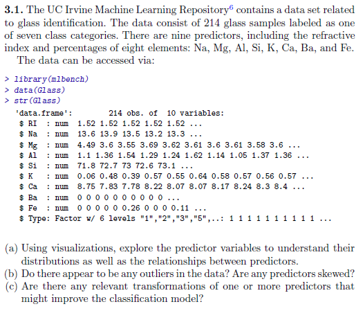

##### **KJ# 3.2**

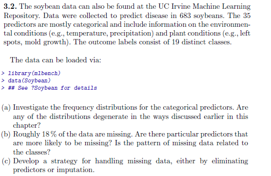

##### **HA# 7.5**

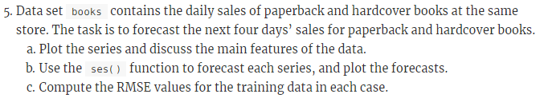

##### a) Plot the series and discuss the main features of the data.

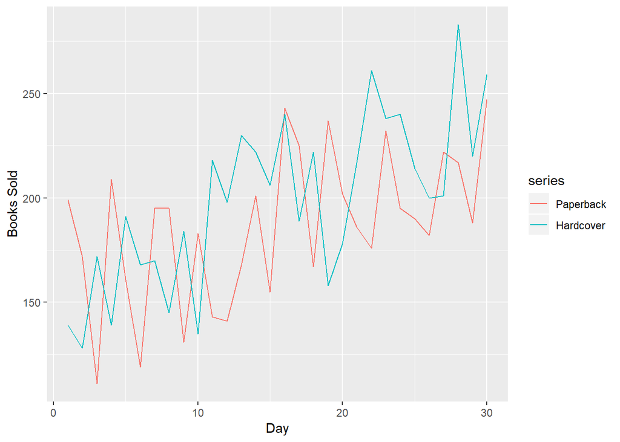

```r
bookdata <- window(books)
autoplot(bookdata) +
  xlab("Day") + ylab("Books Sold")
```

##### b) Use the ses() function to forecast each series, and plot the forecasts.

Plot for Paperback using SES function

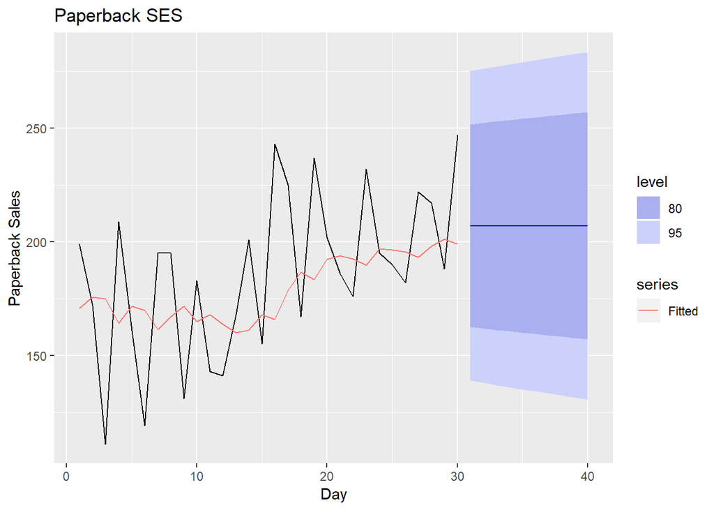

```r
#Simple smoothing for Paperbacks
fc.p <- ses(bookdata[,1])

autoplot(fc.p) +
  autolayer(fitted(fc.p), series="Fitted") +
  ylab("Paperback Sales") + xlab("Day") +
  ggtitle("Paperback SES")
```

Forecast data for Paperbacks

```r
fc.p
```

```
##    Point Forecast    Lo 80    Hi 80    Lo 95    Hi 95
## 31       207.1097 162.4882 251.7311 138.8670 275.3523
## 32       207.1097 161.8589 252.3604 137.9046 276.3147
## 33       207.1097 161.2382 252.9811 136.9554 277.2639
## 34       207.1097 160.6259 253.5935 136.0188 278.2005
## 35       207.1097 160.0215 254.1979 135.0945 279.1249
## 36       207.1097 159.4247 254.7946 134.1818 280.0375
## 37       207.1097 158.8353 255.3840 133.2804 280.9389
## 38       207.1097 158.2531 255.9663 132.3899 281.8294
## 39       207.1097 157.6777 256.5417 131.5099 282.7094
## 40       207.1097 157.1089 257.1105 130.6400 283.5793
```

Plot for Hardcover using SES function

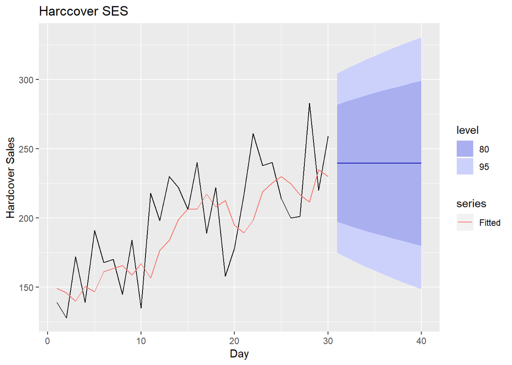

```r
#Simple smoothing for Hardcovers
fc.h <- ses(bookdata[,2])

autoplot(fc.h) +
  autolayer(fitted(fc.h), series="Fitted") +
  ylab("Hardcover Sales") + xlab("Day") +
  ggtitle("Harccover SES")
```

Forecast data for Hardcovers

```r
fc.h
```

```
##    Point Forecast    Lo 80    Hi 80    Lo 95    Hi 95
## 31       239.5601 197.2026 281.9176 174.7799 304.3403
## 32       239.5601 194.9788 284.1414 171.3788 307.7414
## 33       239.5601 192.8607 286.2595 168.1396 310.9806
## 34       239.5601 190.8347 288.2855 165.0410 314.0792
## 35       239.5601 188.8895 290.2306 162.0662 317.0540
## 36       239.5601 187.0164 292.1038 159.2014 319.9188
## 37       239.5601 185.2077 293.9124 156.4353 322.6848
## 38       239.5601 183.4574 295.6628 153.7584 325.3618
## 39       239.5601 181.7600 297.3602 151.1625 327.9577
## 40       239.5601 180.1111 299.0091 148.6406 330.4795
```

##### c) Compute the RMSE values for the training data in each case.

The SES model provides us with the Mean Squared Error already, by calculating the square root of that number we can find the RMSE.

```r
x <- sqrt(fc.p$model$mse)
y <- sqrt(fc.h$model$mse)

print(paste0("RMSE for Paperbacks is ",x))
```

```
## [1] "RMSE for Paperbacks is 33.637686782912"
```

```r
print(paste0("RMSE for Hardcovers is ",y))
```

```
## [1] "RMSE for Hardcovers is 31.9310149844547"
```

##### **HA# 7.6**

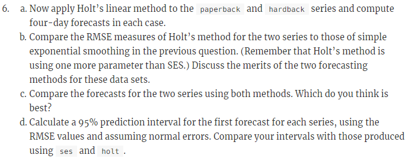

##### a) Apply Holt’s linear method to the paperback and hardback series and compute four-day forecasts in each case.

Holt’s linear method for paperback and the four-day forecasts

```r
#Holt's linear method for Paperback

holt.p <- holt(bookdata[,1], h=4)
holt.p
```

```
##    Point Forecast    Lo 80    Hi 80    Lo 95    Hi 95
## 31       209.4668 166.6035 252.3301 143.9130 275.0205
## 32       210.7177 167.8544 253.5811 145.1640 276.2715
## 33       211.9687 169.1054 254.8320 146.4149 277.5225
## 34       213.2197 170.3564 256.0830 147.6659 278.7735
```

Holt’s linear method for hardcover and the four-day forecasts

```r
#Holt's linear method for Hardcover

holt.h <- holt(bookdata[,2], h=4)
holt.h
```

```
##    Point Forecast    Lo 80    Hi 80    Lo 95    Hi 95
## 31       250.1739 212.7390 287.6087 192.9222 307.4256
## 32       253.4765 216.0416 290.9113 196.2248 310.7282
## 33       256.7791 219.3442 294.2140 199.5274 314.0308
## 34       260.0817 222.6468 297.5166 202.8300 317.3334
```

##### b) Compare the RMSE measures of Holt’s method for the two series to those of simple exponential smoothing in the previous question. (Remember that Holt’s method is using one more parameter that SES). Discuss the merits of the two forecasting methods for these data sets.

```r
hx <- sqrt(holt.p$model$mse)
hy <- sqrt(holt.h$model$mse)

print(paste0("SES RSME for Paperback is ", round(x,2)))
```

```
## [1] "SES RSME for Paperback is 33.64"
```

```r
print(paste0("Holt RSME for Paperback is ", round(hx,2)))
```

```
## [1] "Holt RSME for Paperback is 31.14"
```

```r
cat('\n')
```

```r
print(paste0("SES RSME for Hardcover is ", round(y,2)))
```

```
## [1] "SES RSME for Hardcover is 31.93"
```

```r
print(paste0("Holt RSME for Hardcover is ", round(hy,2)))
```

```
## [1] "Holt RSME for Hardcover is 27.19"
```

The RMSE values for Holt’s linear method are smaller which indicates this method has more accurate predicted values than the simple exponential smoothing method. Both methods use a smoothing level equation which is a weighted average observation between the mose recent observation and the previous one but Holt’s method also uses a trend smoothing equation. This equation calculates the weighted average of the estimated trend at a time based on the current level estimate and previous trend estimate. This method is more accurate especially if the data shows a trend but is also more complicate because of the added variable.

##### c) Compare the forecasts for the two series using both methods. Which do you think is best?

Paperback forecasts

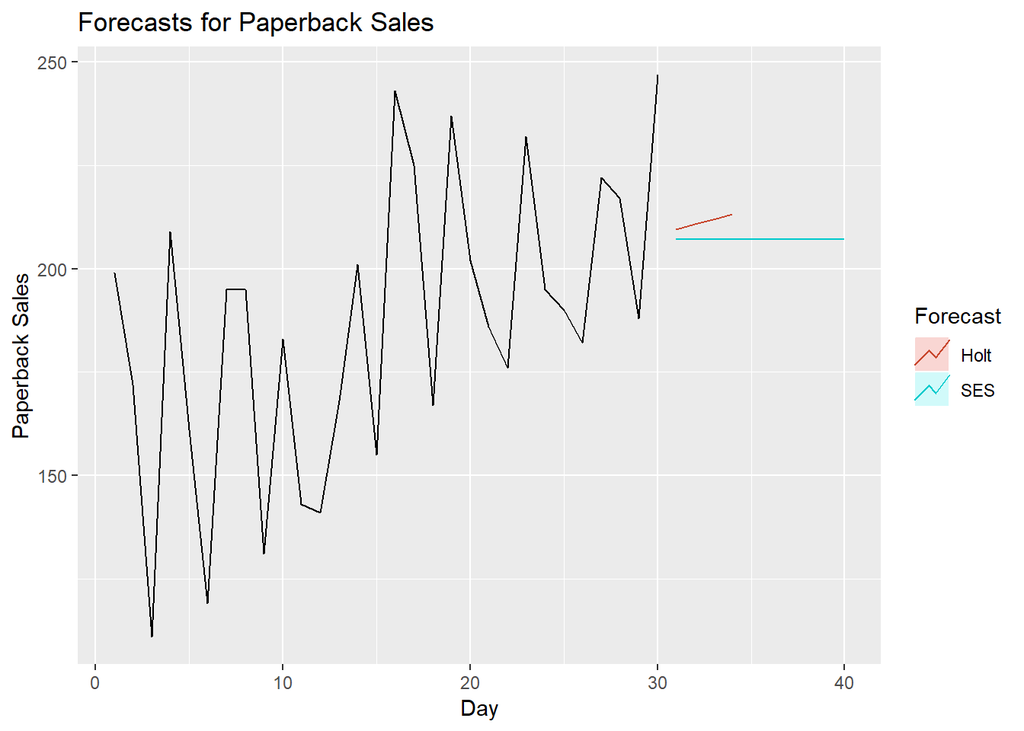

```r
autoplot(bookdata[,1]) +
  autolayer(fc.p, series="SES", PI=FALSE) +
  autolayer(holt.p, series="Holt", PI=FALSE) +
  ggtitle("Forecasts for Paperback Sales") +
  ylab("Paperback Sales") + xlab("Day") +
  guides(colour=guide_legend(title="Forecast"))
```

Hardcover forecasts

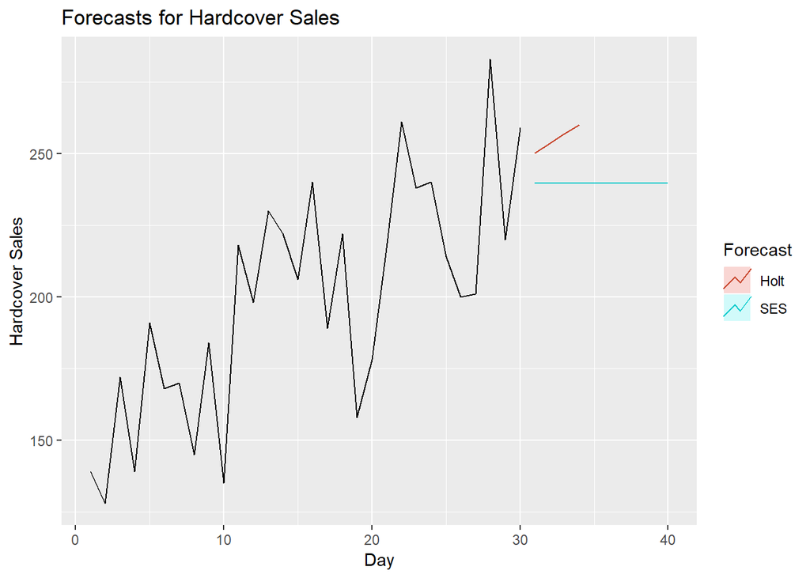

```r
autoplot(bookdata[,2]) +
  autolayer(fc.h, series="SES", PI=FALSE) +
  autolayer(holt.h, series="Holt", PI=FALSE) +
  ggtitle("Forecasts for Hardcover Sales") +
  ylab("Hardcover Sales") + xlab("Day") +
  guides(colour=guide_legend(title="Forecast"))
```

We can see from the plotted forecasts that Holt’s linear method takes into account the slope of the trend. The simple exponential smoothing only uses the last two steps as it’s weighted measures for predictions so Holt’s method is clearly better in this case.

##### d) Calculate a 95% prediction interval for the first forecast for each series using the RMSE values and assuming normal errors. Compare your intervals with those produced using ses and holt.

```r
#SES prediction intervals
pred.pap.ses.low <- bookdata[30,1] - (1.96*x)
pred.pap.ses.high <- bookdata[30,1] + (1.96*x)

pred.hard.ses.low <- bookdata[30,2] - (1.96*y)
pred.hard.ses.high <- bookdata[30,2] + (1.96*y)

pred.pap.holt.low <- bookdata[30,1] - (1.96*hx)
pred.pap.holt.high <- bookdata[30,1] + (1.96*hx)

pred.hard.holt.low <- bookdata[30,2] - (1.96*hy)
pred.hard.holt.high <- bookdata[30,2] + (1.96*hy)

print(paste0("SES Paperback 95% Prediction Interval is [",round(pred.pap.ses.low,2),",",round(pred.pap.ses.high,2),"]"))
```

```
## [1] "SES Paperback 95% Prediction Interval is [181.07,312.93]"
```

```r
print(paste0("SES Hardcover 95% Prediction Interval is [",round(pred.hard.ses.low,2),",",round(pred.hard.ses.high,2),"]"))
```

```
## [1] "SES Hardcover 95% Prediction Interval is [196.42,321.58]"
```

```r
cat()
print(paste0("Holt Paperback 95% Prediction Interval is [",round(pred.pap.holt.low,2),",",round(pred.pap.holt.high,2),"]"))
```

```
## [1] "Holt Paperback 95% Prediction Interval is [185.97,308.03]"
```

```r
print(paste0("Holt Hardcover 95% Prediction Interval is [",round(pred.hard.holt.low,2),",",round(pred.hard.holt.high,2),"]"))
```

```
## [1] "Holt Hardcover 95% Prediction Interval is [205.7,312.3]"
```

The prediction intervals from the two methods show that Holt’s methods have a narrower prediction interval meaning the next forecasted value is more ‘zoned in’ that the SES method. The smaller variance means the calculated error from the actual value is smaller.

##### **HA# 7.10**

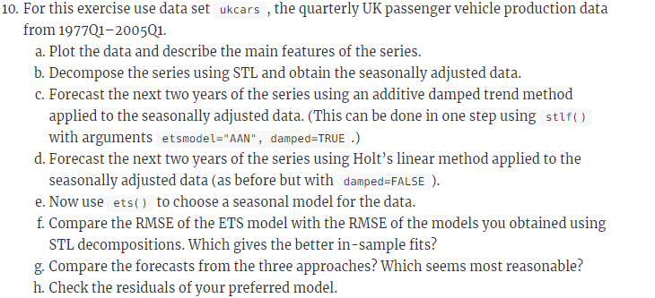

##### a) Plot the data and describe the main features of the series.

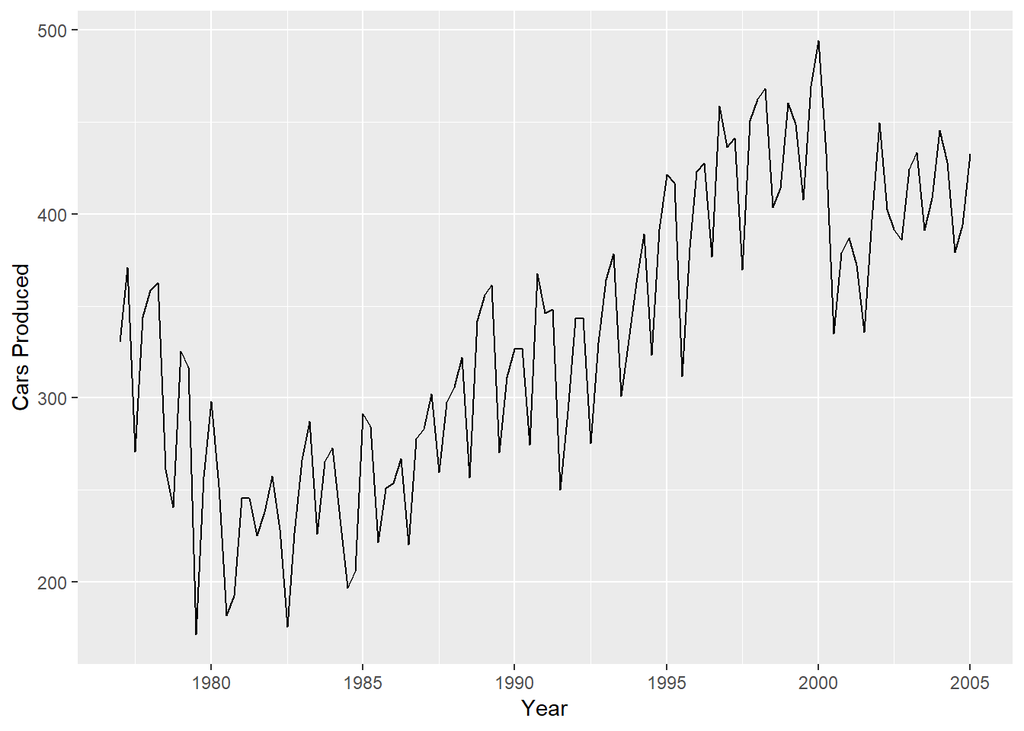

```r
uk <- window(ukcars)

autoplot(uk) +
  ylab("Cars Produced") + xlab("Year")
```

The plot shows that the data has seasonality fluctuations depending on the time of the year. It also shows that the data may have a slight cyclical effect as the trend decreases pre-1980 and after 2000.

##### b) Decompose the series using STL and obtain the seasonally adjusted data.

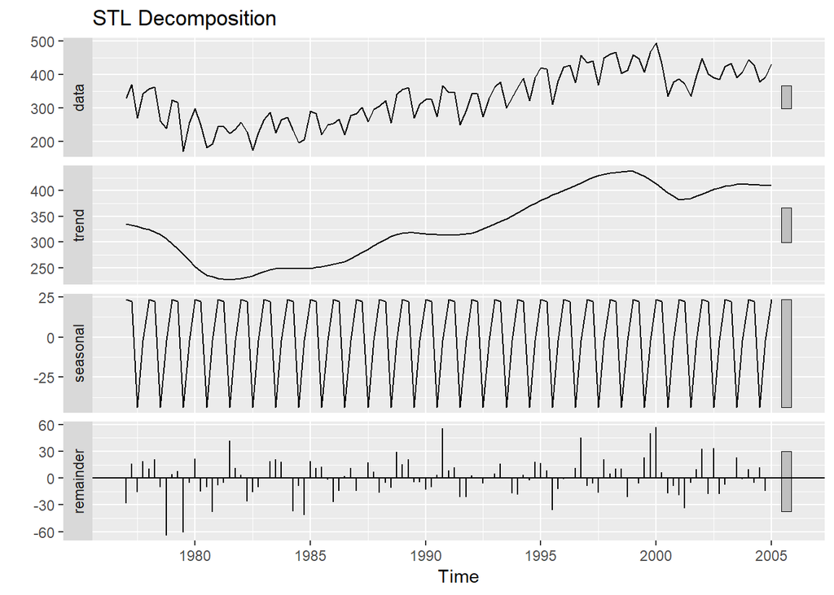

```r
stl.data <- stl(uk, t.window=13, s.window='periodic', robust = TRUE)

autoplot(stl.data) +
  ggtitle("STL Decomposition")
```

STL Seasonal Data Plot

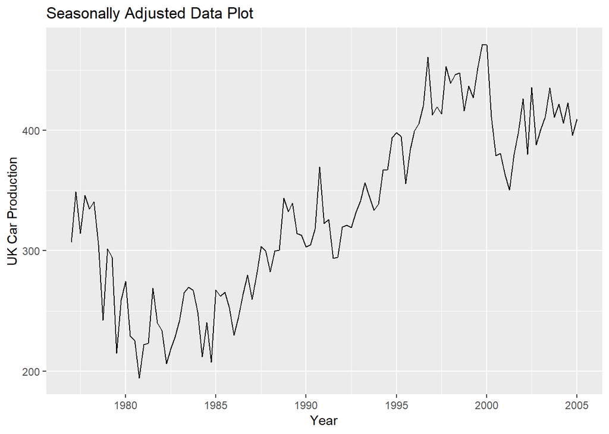

```r
stl.season <- seasadj(stl.data)

autoplot(stl.season) +
  ggtitle("Seasonally Adjusted Data Plot") +
  ylab("UK Car Production") + xlab("Year")
```

Sample of the adjusted seasonal data

```r
head(stl.season, 20)
```

```
##          Qtr1     Qtr2     Qtr3     Qtr4
## 1977 306.7150 348.8871 314.5525 345.8175
## 1978 334.8350 340.6581 305.1635 242.2925
## 1979 301.7260 294.5361 215.0355 259.1545
## 1980 274.4710 229.3001 225.4375 194.5355
## 1981 221.9960 223.3621 269.1435 240.1485
```

##### c) Forecast the next two years of the series using an additive damped trend method applied to the seasonally adjusted data. (This can be done in one step using stlf() with arguments etsmodel=“AAN”, damped=TRUE .)

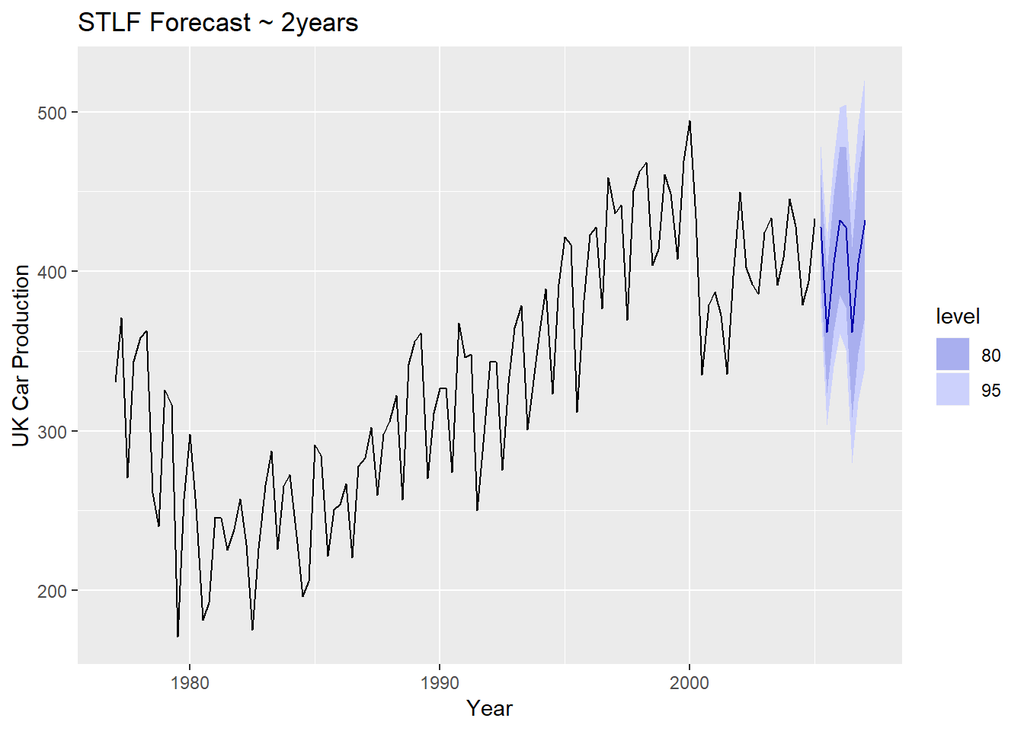

```r
fcast <- stlf(uk, t.window = 13, s.window= 'periodic', etsmodel='AAN', damped=TRUE)

autoplot(fcast) +
  ggtitle("STLF Forecast ~ 2years") +
  xlab("Year") + ylab("UK Car Production")
```

Forecasted mean for next two years.

```r
fcast$mean
```

```
##          Qtr1     Qtr2     Qtr3     Qtr4
## 2005          427.7286 361.7344 405.3316
## 2006 431.8599 427.7269 361.7329 405.3302
## 2007 431.8586
```

##### d) Forecast the next two years of the series using Holt’s linear method applied to the seasonally adjusted data (as before but with damped=FALSE)

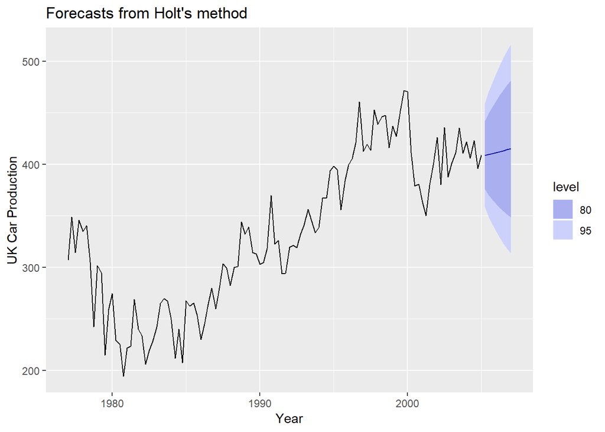

```r
#h=8 for the next 8 quarters (or 2 years)
holt.fc <- holt(stl.season, h=8, damped=FALSE)

autoplot(holt.fc) +
  xlab("Year") + ylab("UK Car Production")
```

Holt’s forecasted mean for next two years.

```r
holt.fc$mean
```

```
##          Qtr1     Qtr2     Qtr3     Qtr4
## 2005          408.6652 409.5661 410.4669
## 2006 411.3678 412.2687 413.1696 414.0704
## 2007 414.9713
```

##### e) Now use ets() to choose a seasonal model for the data.

```r
model <- ets(stl.season)

summary(model)
```

```
## ETS(A,N,N)
##
## Call:
##  ets(y = stl.season)
##
##   Smoothing parameters:
##     alpha = 0.6142
##
##   Initial states:
##     l = 319.3785
##
##   sigma:  25.5059
##
##      AIC     AICc      BIC
## 1270.170 1270.391 1278.353
##
## Training set error measures:
##                    ME     RMSE      MAE        MPE    MAPE      MASE
## Training set 1.268191 25.27916 20.09488 -0.1399071 6.45961 0.6548825
##                    ACF1
## Training set 0.02823545
```

The ETS function has chosen model ETS(A,N,N) as the model of best fit.

##### f) Compare the RMSE of the ETS model with the RMSE of the models you obtained using STL decompisitions. Which gives the better in-sample fits?

```r
fcast.rmse <- sqrt(fcast$model$mse)

holt.rmse <- sqrt(holt.fc$model$mse)

ets.rmse <- sqrt(model$mse)

print(paste0("RMSE for the STLF method is: ", fcast.rmse))
```

```
## [1] "RMSE for the STLF method is: 25.1579382775701"
```

```r
cat('')
print(paste0("RMSE for the HOLT LINEAR method is: ", holt.rmse))
```

```
## [1] "RMSE for the HOLT LINEAR method is: 25.2823673244667"
```

```r
cat()
print(paste0("RMSE for the ETS method is: ", ets.rmse))
```

```
## [1] "RMSE for the ETS method is: 25.2791607367545"
```

```r
cat()
```

Though they are all very close, the STLF method does have a better fit when comparing RMSE’s.

##### g) Compare the forecasts from the three approaches. Which seems most reasonable?

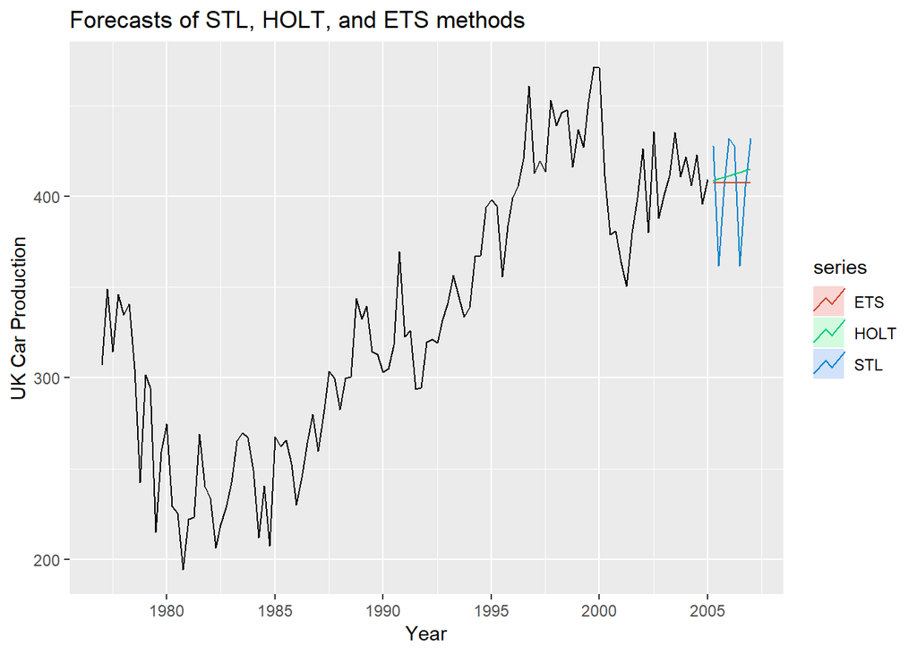

```r
ets.fc <- model %>%
  forecast(h=8)

autoplot(stl.season) +
  autolayer(fcast, series="STL", PI=FALSE) +
  autolayer(holt.fc, series="HOLT", PI=FALSE) +
  autolayer(ets.fc, series="ETS", PI=FALSE) +
  ggtitle("Forecasts of STL, HOLT, and ETS methods") +
  xlab("Year") + ylab("UK Car Production")
```

The STL model resembles a more realistic forecast compared to the other two. However, the holt model does include the increasing trend from 1980 forward. The data may also show a cyclical pattern where after 2000 the trend starts to decline which may give ETS an advantage.

##### h) Check the residuals of your preferred model.

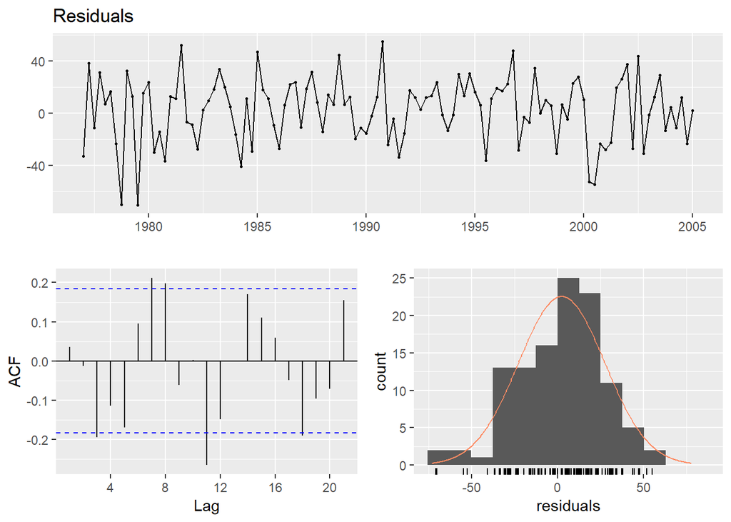

```r
checkresiduals(fcast$residuals)
```

The lag plot shows that 5 autocorrelations are beyond the critical value boundaries. There is also a seaonal trend that is apparent so the ACF plot is not stationary.

##### **HA# 8.1**

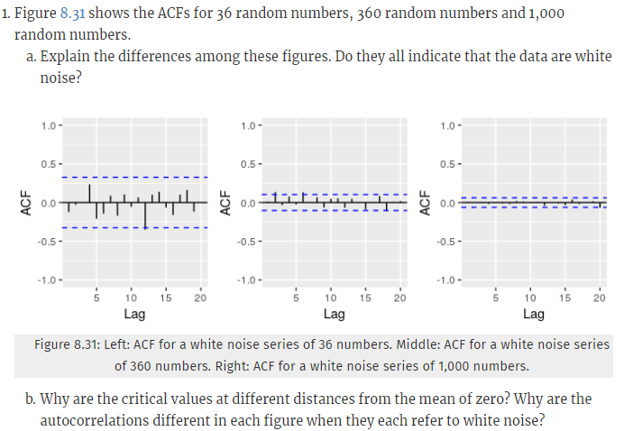

##### a) Explain the differences among these figures. Do they all indicate that the data is white noise?

For these plots I would expect no more than 5% of the lags to exceed the 95% interval boundaries. Since only 20 lags are shown in the plots we have to make assumptions. If the plot is stationary then the properties do not depend on the time at which the series is observed. For the first plot, 1 out of 20 lags is beyond the boundary which is 5%. This could still be white noise but more tests should be done. The second plot has 3 out of 20 which is beyond 5% meaning this is not white noise. The third plot doesn’t show any white does represent white noise. As for all the plots, there does not seem to be any apparent pattern or structure to the plots.

##### b) Why are the critical values at different distances from the mean of zero? Why are the autocorrelations different in each figure when they each refer to white noise?

The critical values are at different distances becuase of the equation
$$\frac{2\pm }{ \sqrt{T}}$$
where
$$T$$
is the number of values used. Since plot 1 has 36 random numbers the critical values are
$$\frac{2\pm }{ \sqrt{36}}$$
or
$$\pm 0.33$$
.

The autocorrelations should be as close to zero as possible if it is white noise. As more lags become available, the confidence that the next lag will be near zero will be high. This is why the critical values shrink closer to zero with more numbers.

##### **HA# 8.2**

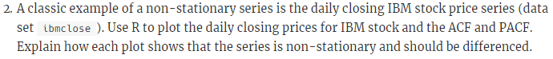

##### **HA# 8.7**

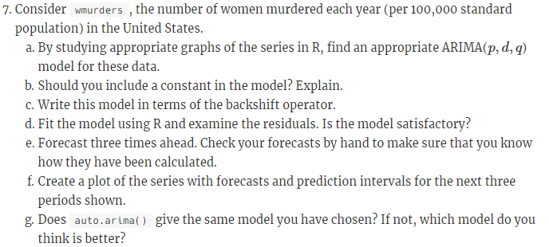

##### **HA# 8.12**

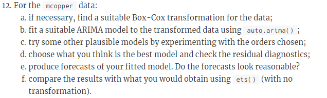